# Data Science Capstone Project: Milestone Report

Author: Anderson R. S. dos Santos

The goal of this project is to try to predict the next word in a sentence. In order to do that we are going to use an text corpus called HC Corpora (www.corpora.heliohost.org). This corpus were collected from different sources: blogs, newspapers, magazines and twitter posts.

We are going to use some Natural Language Processing techniques to process the corpus and extract the statistical knowledge necessary for the model. First, we are going to pre-process and clean the corpus.

**What we have done so far:**

1. Made some basic exploration around the corpus files
2. Load a sub-sample of the corpus into R
3. Transformations and cleaning process on the data:
   1. Tokenize it into words
   2. Set all letters to lowercase
   3. Remove some profanity words
   4. Remove numbers
   5. Remove ponctuation
4. Exploring the frequencies of words

## Basic Exploratory Analysis

Let's explore some basic attributes of our corpora:

```r
filesStatList <- getGeneralTextStats("Data/final/en_US/en_US.*")
```

| Source name | Number of lines | Number of words | Longest line | Size (MB) |
| --- | --- | --- | --- | --- |
| blogs | 899288 | 37334114 | 40833 | 200.424207687378 |
| news | 1010242 | 34365936 | 11384 | 196.277512550354 |
| twitter | 2360148 | 30359804 | 173 | 159.364068984985 |
| total | 4269678 | 102059854 | 40833 | 556.065789222717 |

## Pre-processing and cleaning

1. **Sub-sample the data files.**
2. **Remove punctuation and numbers:** For our task of predicting the next word, numbers and ponctuation does not seems to improve results.
3. **Set all letters to lowercase**
4. **Profanity filtering:** Removing profanity words that we do not want to predict.
5. **Tokenization:** Identifying appropriate tokens such as words, punctuation, and numbers.

## Deeper Exploratory Analysis

### Term frequency

```r
## By default, will sample 1000 lines
blogCorpus <- getSampleCorpus('blogs',filesStatList)
newsCorpus <- getSampleCorpus('news',filesStatList)
twitterCorpus <- getSampleCorpus('twitter',filesStatList,linesToRead = 6000)

## Do the preprocessing steps
blogCorpus <- preProcessCorpus('blogs',corpusObj = blogCorpus)
newsCorpus <- preProcessCorpus('news',corpusObj = newsCorpus)
twitterCorpus <- preProcessCorpus('twitter',corpusObj = twitterCorpus,linesToRead = 6000)

blogUnigramTDM <- TermDocumentMatrix(blogCorpus)
newsUnigramTDM <- TermDocumentMatrix(newsCorpus)
twitterUnigramTDM <- TermDocumentMatrix(twitterCorpus)
```

Let's explore the word frequencies in all three corpus: twitter, blogs and news. As can be seen in the plots bellow, there are few words with high frequency a the most words have lower frequency.

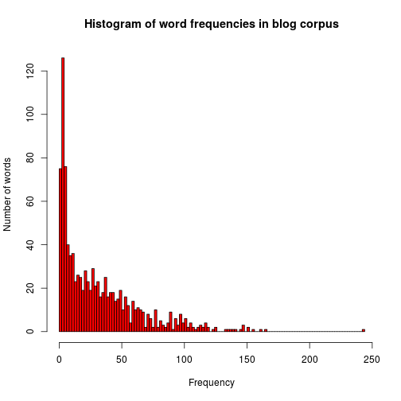

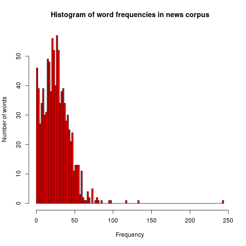

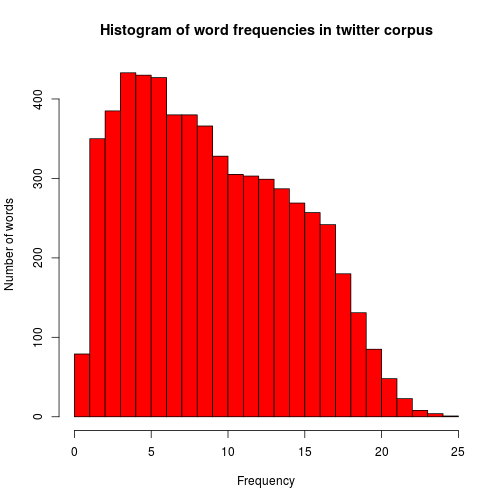

## Next steps for the project

Some needed definitions: **ngrams:** n-gram is a contiguous sequence of n words in a text. **ngram modeling:** ngram modeling is the task of extracting the probability of a given ngram (sequence of words) in a corpus. This is usefull for predicting the probability of given word based on the last “n-1” words.

1. In the cleaning process:
   1. Identify and remove URLS
   2. Change dots that means etc. to “, ”. eg.:
      - “local rapper Pashion…Copped her CD from her”
      - “rest of world uses MARC21 or USMARC.. In France, we don't like”
      - “Back to black hair Friday… Maybe”
2. In the modeling process:
   1. Create 2 and 3 ngram models
   2. Create and test the first model of 3-gram
   3. Test some other tools: backoff and smoothing (to treat unseen words or ngrams) …
   4. Evaluate and choose the best model
3. Create the prediction function
4. Create the shiny app